# R Markdown: Introduction

## What do we want to be able to do?

Data Science

- Scrape, read, and manipulate data
- Combine data sources
- Summarize data
- Apply analysis methods
- Communicate Effectively

## Recap So Far - Basics of R

- Attributes and Structure important to understand
  - `attributes()`
  - `str()`
- Accessing common data structures
  - Atomic vectors - `x[ ]`
  - Matrices - `x[ , ]`
  - Data Frames - `x[ , ]` or `x$name`
  - Lists - `x[[ ]]` or `x$name`

## (Traditional) Basic Use of R

- Usually want to keep code for later use
- Write code in a 'script'
- Save code script
- Send lines of code to console via:
  - "Run" button (runs current line)
  - CTRL+Enter (PC) or Command+Enter (MAC)
  - Highlight section and do above

## Using a Notebook Instead

- Communication and reproducibility vital!
- May have heard of [JUPYTER](http://jupyter.org/) notebooks
- R Markdown - built in notebook for R studio
- [Intro video](https://www4.stat.ncsu.edu/~post/IntermediateR/video/Markdown.mp4)

## R Markdown Basics

**What is Markdown?**

- Formatting syntax for authoring HTML, PDF, slide shows, books, and more.
- Digital "Notebook": Program that weaves word processing and code.

## R Markdown Basics

**What is Markdown?**

- Formatting syntax for authoring HTML, PDF, slide shows, books, and more.
- Digital "Notebook": Program that weaves word processing and code.
- Designed to be used in three ways (R for Data Science)
- Communicating to decision makers (focus on conclusions not code)
- Collaborating with other data scientists (including future you!)
- As environment to do data science (documents what you did and what you were thinking)

## R Markdown Basics

**Verbage**

- Most have heard of HTML (HyperText Mark-up Language)
  - Write plain text that the browser interprets and renders

## R Markdown Basics

**Verbage**

- Most have heard of HTML (HyperText Mark-up Language)
  - Write plain text that the browser interprets and renders
- Markdown is a specific markup language
  - Easier syntax
  - Not as powerful
- Any plain text file can be used (.Rmd extension associates it with R Studio)

## R Markdown Basics

**R Markdown Basics**

R Markdown file contains three important types of content:

1. (Optional) YAML header surrounded by `---`s
2. Chunks of R code surrounded by ```
3. Text mixed with simple text formatting like # heading and *italics*

## R Markdown Basics

**Creating an R Markdown Document**

- R Studio makes it easy!

[figure not shown]

## R Markdown Basics

**Creating an R Markdown Document**

- Commonly used document types can be created

[figure not shown]

## R Markdown Basics

**Creating an R Markdown Document**

- Slide presentations

[figure not shown]

## R Markdown Basics

**Creating an R Markdown Document**

- Truly Interactive Documents/Pages (requires R backend)

[figure not shown]

## R Markdown Basics

- Create an HTML Markdown document!

  ```
  ---
  title: "Untitled"
  author: "Justin Post"
  date: "August 10, 2017"
  output: html_document
  ---
  ```

- Top section: YAML header
- Define settings for document
- Author, Title, etc.
- Output type/Options

## R Markdown Basics

- Below YAML header: 'r chunk'

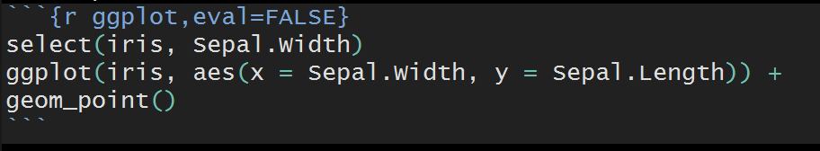

- Start code chunk by typing ```{r} out or with CTRL/CMD + Alt + I
- Code will be executed when document is created
- Can specify options on individual code chunks

## R Markdown Basics

- Below code chunk is plain text with markdown sytnax

```
## R Markdown

This is an R Markdown document. Markdown is a simple formatting syntax
for authoring HTML, PDF, and MS Word documents. For more details on
using R Markdown see <http://rmarkdown.rstudio.com>.

When you click the **Knit** button a document will be generated that
includes both content as well as the output of any embedded R code
chunks within the document.
```

- When file created, "##" becomes a header, "<…>" a link, and `**Knit**` bold font

## R Markdown Basics

## Where do we go from here?

- Figure out markdown syntax
- Look at "Notebook" feature
- Check options for code chunks
- Change type of output